# Project on F.R.I.E.N.D.S

## B - Viewership Trend

**Aggregating & Plotting**

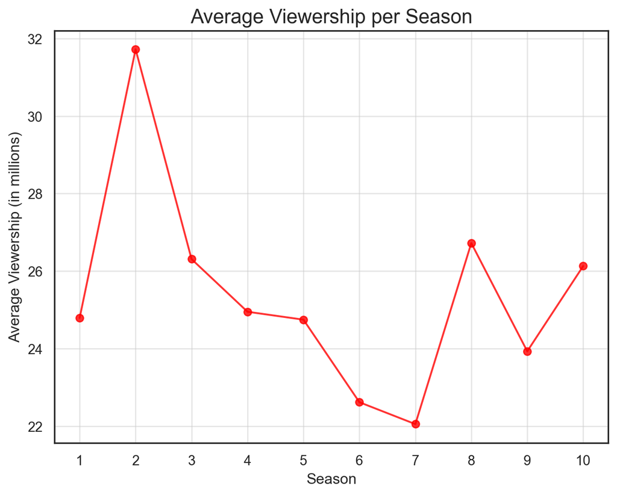

```python
# Aggregating
season_views = info_df.groupby("season")["us_views_millions"].mean().reset_index()

# Plotting
plt.figure(figsize = (8, 6))
plt.plot(season_views["season"], season_views["us_views_millions"], marker = "o", linestyle = "-", color = "red", alpha = 0.8)
plt.title("Average Viewership per Season", fontsize = 16)
plt.xlabel("Season", fontsize = 12)
plt.ylabel("Average Viewership (in millions)", fontsize = 12)
plt.xticks(season_views["season"])
plt.grid(alpha = 0.5)
plt.show()
```

# 2 - Character Dialogue Domination👑

## A - Per Season

**Aggregating Dialogue Count by Season**

```python
# Grouping
dominant_dialogue_ss = (friends_df.groupby(['season', 'speaker']).size().reset_index(name = 'dialogue_count'))
dominant_character_ss = dominant_dialogue_ss.loc[dominant_dialogue_ss.groupby(['season'])['dialogue_count'].idxmax()].reset_index(drop = True)
```

**Plotting Most Dominant Character**

```python
# Original Plot
fig_ss = px.bar(
    dominant_character_ss, x = "season", y = "dialogue_count", color = "speaker", title = "Most Dominant Character by Season",
    labels = {"season": "Season", "dialogue_count": "Dialogue Count", "speaker": "Character"}
)

# Updating Plot
fig_ss.update_layout(
    title={
        'text': "Most Dominant Character by Season", 'x': 0.5, 'xanchor': 'center', 'yanchor': 'top', 'font': dict(size = 16),
    },
    showlegend = True, legend_title_text = "Character"
)

# Updated Plot
fig_ss.show()
```

[interactive chart not shown]

## A - Per Episode

**Aggregating Dialogue Count by Character**

```python
# Grouping to No of Dialogues for Each Character
dominant_dialogue_ep = (friends_df.groupby(['season', 'episode', 'speaker']).size().reset_index(name = 'dialogue_count'))

# Finding Character with MAX Dialogue Count
dominant_character_ep = dominant_dialogue_ep.loc[dominant_dialogue_ep.groupby(['season', 'episode'])['dialogue_count'].idxmax()].reset_index(drop = True)

# Filtering out "Scene Directions"
filtered_dialogue_ep = dominant_dialogue_ep[dominant_dialogue_ep["speaker"] != "Scene Directions"]

# Identify 2nd Most Dominant if "Scene Directions" was the Original Dominant
dominant_character_ep = (filtered_dialogue_ep.loc[filtered_dialogue_ep.groupby(['season', 'episode'])['dialogue_count'].idxmax()]).reset_index(drop = True)
```

**Plotting Most Dominant Character**

```python
# Plotting the Most Dominant Character by Episode
fig_ep = px.bar(
    dominant_character_ep,
    x = "episode",
    y = "dialogue_count",
    color = "speaker",
    facet_row = "season",
    title = "Most Dominant Character by Episode",
    labels = {"episode": "Episode", "dialogue_count": "", "speaker": "Character"},
    height = 600,
    facet_row_spacing = 0.03,
)

# Customizing Layout
fig_ep.update_layout(
    title={
        'text': "Most Dominant Character by Episode",
        'x': 0.5,
        'xanchor': 'center',
        'yanchor': 'top',
        'font': dict(size = 16)
    }
)

# Updating Layout
fig_ep.update_layout(
    showlegend = True,
    legend_title_text = "Character",
    yaxis_title = "Dialogue Count",
    uniformtext_minsize = 10,
    uniformtext_mode = "hide",
    margin = dict(l = 50, r = 50, t = 50, b = 50),
)

# Updating Y-Axis
fig_ep.update_yaxes(
    title_standoff = 0,
    visible = False,
    title=dict(text = "Dialogue Count", font = dict(size = 14), standoff = 20)
)

# Customizing Facet Row Labels
fig_ep.for_each_annotation(lambda a: a.update(text=f"{a.text.split('=')[-1]}"))

# Adding Custom Annotation for "Dialogue Count"
fig_ep.add_annotation(
    text = "Dialogue Count", x = -0.04, xref = "paper", y = 0.5, yref = "paper",
    showarrow = False, font = dict(size = 14), textangle = -90
)

# Adding Custom Annotation for "Season"
fig_ep.add_annotation(
    text = "Season", x = 1.04, xref = "paper", y = 0.5, yref = "paper",
    showarrow = False, font = dict(size = 14), textangle = 90
)

# Displaying
fig_ep.show()
```

[interactive chart not shown]

# 3 - Emotional Tone Analysis💬

Initially, the `friends_emotions.csv` dataset was intended for emotional labeling, but it provides a limited coverage of emotionally-labelled dialogues (approx. 12k). Instead, sentiment analysis was conducted using TextBlob and BigBird models. Due to the high computational demands of processing the dataset with the models, they were written and executed separately from the website environment. The results obtained from both of the models are stored in `data/tone_model_outputs` directory, from where they will be imported below for visualization purposes. However, if you’re interested in examining the model codes yourself, they are provided in `tone_models` folder in the root directory.

## A - TextBlob

**Plotting Sentiment Analysis**

```python
# Importint Dataset
tb_sentiment = pd.read_csv('data/tone_model_outputs/textblob_sentiment.csv')

# Original Plot
fig_donut = px.pie(
    tb_sentiment, names = "speaker", values = "polarity",
    title = "Emotional Tone Distribution (Polarity) - OG6", hole = 0.5,
    color_discrete_sequence = px.colors.sequential.Turbo
)

# Updating Plot
fig_donut.update_layout(
  title = {
    'text': "Emotional Tone Distribution for F.R.I.E.N.D.S", 'x': 0.5,
    'xanchor': 'center', 'yanchor': 'top', 'font': dict(size = 16)
  },
  height = 500, width = 600,
  margin = dict(t = 50, b = 50, l = 50, r = 50)
)

# Displaying
fig_donut.show()
```

[interactive chart not shown]

## B - BigBird

**Plotting Sentiment Analysis**

```python
# Importing Dataset
bb_sentiment = pd.read_csv('data/tone_model_outputs/bigbird_sentiment.csv')

# Original Plot
fig_donut = px.pie(
    bb_sentiment, names = "speaker", values = "bigbird_polarity",
    title = "Emotional Tone Distribution (Polarity) - OG6", hole = 0.5,
    color_discrete_sequence = px.colors.sequential.Turbo
)

# Updating Plot
fig_donut.update_layout(
  title = {
    'text': "Emotional Tone Distribution for F.R.I.E.N.D.S", 'x': 0.5,
    'xanchor': 'center', 'yanchor': 'top', 'font': dict(size = 16)
  },
  height = 500, width = 600,
  margin = dict(t = 50, b = 50, l = 50, r = 50)
)

# Displaying
fig_donut.show()
```

[interactive chart not shown]